# Meta-analysis with `glmmTMB` package `equalto` covariance structure

Author

Coralie Williams

Published

September 3, 2025

# 1 Overview

This webpage describes the `equalto` covariance structure within the `glmmTMB` package to fit meta-analytical models.

First, let’s load the packages needed.

```r
# load packages
library(MASS)
library(metafor)
library(nlme)
library(kableExtra, verbose=F)
library(insight) #to get degrees of freedom
library(microbenchmark) #for evaluating speed of functions
library(ape); library(MASS)
library(brms)
library(here)
```

We will install `glmmTMB` using the following branch: https://github.com/coraliewilliams/glmmTMB/tree/equalto_covstruc.

```r
# remove glmmTMB (if installed) and reload R
remove.packages("glmmTMB")

# build package from branch: https://github.com/coraliewilliams/glmmTMB/tree/equalto_covstruc
remotes::install_github("coraliewilliams/glmmTMB", ref="equalto_covstruc", subdir="glmmTMB")
```

Check if `equalto` covariance structure is there:

```r
# load it
library(glmmTMB)
# check the available covstruc (you should see equalto in number 13)
(glmmTMB:::.valid_covstruct)
```

```
   diag      us      cs     ar1      ou     exp     gau     mat    toep      rr
      0       1       2       3       4       5       6       7       8       9
homdiag  propto  hetar1 equalto
     10      11      12      13
```

# 2 First test

For the first test we are interested in fitting a multilevel meta-analysis model that synthesises effect sizes across studies by accounting for variability at the study level, at the observation (effect size) level, and by modelling correlated within-study residual errors.

We specify the model as
$$y_{ij} = b_0 + u_i + m_{ij} + e_{ij},$$

where $i$ indexes studies and $j$ indexes effect sizes within study $i$. Here, $b_0$ is the overall mean effect, $u_i \sim N(0, \sigma^2_{u}I)$ represents the among-study random effect, $m_{ij} \sim N(0, \sigma^2_{m}I)$ captures the within-study random effect (at the observation-level), and $e_{ij} \sim N(0, \text{VCV})$ are the sampling errors at the observation-level. $\text{VCV}$ represents a block-diagonal variance-covariance matrix including known (or calculated) sampling variances $\sigma^2_{e}=v_i$ on the diagonal and accounts for correlations among sampling errors from the same study.

### 2.0.1 Simulate some data

Now let’s simulate data following the structure of the above multilevel meta-analysis.

```r
# set up indices
set.seed(123)
k.studies <- 50 # number of studies
k.per.study <- 10 # number of effect sizes per study
study <- rep(seq_len(k.studies), times=k.per.study) # study id
k <- length(study) # total number of effect sizes
id <- seq_len(k) # id of between study effect sizes
es.id <- unlist(lapply(k.per.study, seq_len)) # id of within study effect sizes


# fixed effect coeff true value (i.e. the overall mean)
b0 <- 0

# simulate sampling errors variances
vi <- rbeta(k, 2, 20)

# get VCV matrix assuming within-study correlation of rho=0.5
V <- matrix(0, nrow = k, ncol = k)
for (i in 2:k) {
  for (j in 1:i) {
    if (study[i] == study[j]) {
      V[i,j] <- 0.5 * sqrt(vi[i] * vi[j])
    }
  }
}
V[upper.tri(V)] <- t(V)[upper.tri(V)] # fill in upper diagonal
diag(V) <- vi # fill in diagonal


# random effects
sigma2.u <- 0.2
sigma2.m <- 0.3
u <- rnorm(k.studies, 0, sqrt(sigma2.u))[study]
m <- rnorm(k, 0, sqrt(sigma2.m))
#e <- rnorm(k, 0, sqrt(vi))[study] #without within-study correlation (diag VCV)
e <- mvrnorm(n = 1, mu = rep(0, length(vi)), Sigma = V)


# compute y
y <- b0 + u + m + e


# combine into dataframe
dat <- data.frame(y = y,
                  vi = vi,
                  study = study,
                  id = id,
                  es.id = es.id,
                  obs = as.factor(id), #unique ID for propto and equalto (really important it is a factor variable)
                  g = 1 #group ID for propto and equalto (a constant here)
)
```

### 2.0.2 Run model

Before we fit the glmmTMB model we need to obtain the within-study error variance-covariance matrix (which accounts for within-study correlation) assuming a constant correlation of $\rho=0.5$. The correlation between effect sizes from different studies is assumed to be zero.

```r
VCV <- vcalc(vi, cluster=study, obs=obs, data=dat, rho=0.5)
```

Now we fit the glmmTMB model. We specify the study-level random effect $u_i$ as `(1|study)`, the sampling errors $e_{ij}$ are specified using the covariance structure `equalto(0 + obs|g,VCV)` allowing to specify the known/calculated VCV matrix. The $m_{ij}$ within-study random effect that captures the variability at the observation level is modelled as the residual error in this model.

```r
#Fit glmmTMB model with equalto --------------------------------------------
fit.equalto <- glmmTMB(y ~ 1 + (1|study) + equalto(0 + obs|g,VCV),
                       data=dat,
                       REML=T)
```

Let’s compare with the `metafor` package `rma.mv` function that fits a multilevel model with random effects. Here the model is specified with two random effects: `(1|study)` and `(1|id)`, corresponding to the among-study ($u_i$) and within-study ($m_{ij}$) random effects, respectively. The sampling errors $e_{ij}$ VCV matrix is specified using the `V` argument.

```r
# Fit metafor model
fit.metafor <- rma.mv(y, VCV,
                      random = list(~1 | study, ~1 | id),
                      test = "t",
                      dfs = "contain",
                      data=dat) #used REML by default

##### Compare output
metafor <- data.frame(model = "metafor",
                      est = fit.metafor$b[[1]],
                      se = fit.metafor$se[[1]],
                      zval = fit.metafor$zval,
                      pval = fit.metafor$pval,
                      sigma.u = sqrt(fit.metafor$sigma2[1]), ## among study variance
                      sigma.m = sqrt(fit.metafor$sigma2[2]), ## withins study variance
                      sigma.total = sum(sqrt((fit.metafor$sigma2))),
                      logLik = logLik(fit.metafor)[1],
                      df = attr(logLik(fit.metafor), "df"), ## model-based
                      df.res = df.residual(fit.metafor)) ## residual df

equalto <- data.frame(model = "equalto",
                      est = unlist(fixef(fit.equalto))[[1]],
                      se = as.numeric(sqrt(vcov(fit.equalto)[[1]])),
                      zval = summary(fit.equalto)$coefficients$cond[3],
                      pval = summary(fit.equalto)$coefficients$cond[4],
                      sigma.u = exp(fit.equalto$fit$par[[2]]), ##among study variance estimate
                      sigma.m = sigma(fit.equalto), ##within study variance estimate
                      sigma.total = sum(exp(fit.equalto$fit$par)),
                      logLik = logLik(fit.equalto),
                      df = attr(logLik(fit.equalto), "df"), ## model-based df
                      df.res = df.residual(fit.equalto)) ## residual df


output <- rbind(metafor, equalto)
kable(output)
```

| model | est | se | zval | pval | sigma.u | sigma.m | sigma.total | logLik | df | df.res |
| --- | --- | --- | --- | --- | --- | --- | --- | --- | --- | --- |
| metafor | -0.0621239 | 0.0787740 | -0.7886343 | 0.4341249 | 0.4887451 | 0.5597119 | 1.048457 | -508.1780 | 3 | 499 |
| equalto | -0.0621239 | 0.0787833 | -0.7885417 | 0.4303799 | 0.4887451 | 0.5597119 | 1.048457 | -511.2853 | 3 | 497 |

The overall mean estimate and random effect variance estimates are identical across the two packages. To note though: the standard errors differ to the fourth decimal point (and hence also the z-value and p-value), as well as the log-likelihoods and residual degrees of freedom (which is expected? => see notes in glmmTMB about df).

# 3 Comparison of three R packages

Let’s compare the model estimates of `glmmTMB` across two other R packages: `metafor` and `nlme`. We use code has from [this blog post](https://jepusto.com/posts/Bug-in-nlme-with-fixed-sigma/) by J.E.Pustejovsky.

We will fit three types of models:

- a basic random effect model
- a bivariate random effect model
- a three-level random effect model

We will store the model estimates, standard errors, degrees of freedom and log-likelihoods of the models fitted to three R packages. We also store the estimated standard deviation of the underlying true effect sizes across studies, $\tau$ (also called the between-study heterogeneity).

## 3.1 Basic random effect

Using BCG vaccine data from `metafor` package:

```r
bcg_example <- function(method = "REML", constant_var = FALSE) {

  data(dat.bcg)
  dat <- escalc(measure="OR", ai=tpos, bi=tneg, ci=cpos, di=cneg, data=dat.bcg)
  dat$g <- 1
  dat$trial <- as.factor(dat$trial)

  v_bar <- mean(dat$vi)
  if (constant_var) dat$vi <- v_bar



  # random-effects model using rma.uni()
  LOR_uni_fit <- rma(yi, vi, data=dat, method = method)
  LOR_uni <- with(LOR_uni_fit,
                  data.frame(f = "rma.uni",
                             logLik = logLik(LOR_uni_fit),
                             df = attr(logLik(LOR_uni_fit), "df"),
                             est = as.numeric(b),
                             se = se,
                             tau = sqrt(tau2)))



  # random-effects model using rma.mv()
  LOR_mv_fit <- rma.mv(yi, vi, random = ~ 1 | trial, data=dat, method = method)
  LOR_mv <- with(LOR_mv_fit,
                 data.frame(f = "rma.mv",
                            logLik = logLik(LOR_mv_fit),
                            df = attr(logLik(LOR_mv_fit), "df"), #model-based dfs, i.e. the number of (estimated) params
                            est = as.numeric(b),
                            se = se,
                            tau = sqrt(sigma2)))


  # random-effects model using lme()
  if (constant_var) {
    LOR_lme_fit <- lme(yi ~ 1, data = dat, method = method,
                       random = ~ 1 | trial,
                       control = lmeControl(sigma = sqrt(v_bar)))
    tau <- sqrt(as.numeric(coef(LOR_lme_fit$modelStruct$reStruct, unconstrained = FALSE)) * v_bar)
  } else {
    LOR_lme_fit <- lme(yi ~ 1, data = dat, method = method,
                       random = ~ 1 | trial,
                       weights = varFixed(~ vi),
                       control = lmeControl(sigma = 1))
    tau <- sqrt(as.numeric(coef(LOR_lme_fit$modelStruct$reStruct, unconstrained = FALSE)))
  }
  LOR_lme <- data.frame(f = "lme",
                        logLik = logLik(LOR_lme_fit),
                        df = attr(logLik(LOR_lme_fit), "df"),
                        est = as.numeric(fixef(LOR_lme_fit)),
                        se = as.numeric(sqrt(vcov(LOR_lme_fit))),
                        tau = tau)


  # random-effects model using glmmTMB() and equalto
  if (method=="REML") REML <- TRUE else REML <- FALSE

  if (constant_var) {
    VCV <- diag(v_bar, nrow = nrow(dat))
    LOR_glmm_fit <- glmmTMB(yi ~ 1 + equalto(0 + trial|g,VCV),
                            REML = REML,
                            data=dat)
    tau <- sigma(LOR_glmm_fit)
  } else {
    VCV <- diag(dat$vi)
    LOR_glmm_fit <- glmmTMB(yi ~ 1 + equalto(0 + trial|g,VCV),
                            REML = REML,
                            data=dat)
    tau <- sigma(LOR_glmm_fit)
  }
  LOR_glmm <- data.frame(f = "glmmTMB",
                        logLik = logLik(LOR_glmm_fit)[1],
                        df = attr(logLik(LOR_glmm_fit), "df"),
                        est = as.numeric(unlist(fixef(LOR_glmm_fit))[[1]]),
                        se = as.numeric(sqrt(vcov(LOR_glmm_fit)[[1]])),
                        tau = tau)


  ## compare models
  kable(rbind(LOR_uni, LOR_mv, LOR_glmm, LOR_lme))

}

bcg_example("REML", constant_var = FALSE)
```

| f | logLik | df | est | se | tau |
| --- | --- | --- | --- | --- | --- |
| rma.uni | -12.57566 | 2 | -0.7451778 | 0.1860279 | 0.5811816 |
| rma.mv | -12.57566 | 2 | -0.7451778 | 0.1860280 | 0.5811818 |
| glmmTMB | -13.85814 | 2 | -0.7451778 | 0.1866227 | 0.5811816 |
| lme | -13.34043 | 2 | -0.7471979 | 0.1916902 | 0.6030524 |

```r
bcg_example("REML", constant_var = TRUE)
```

| f | logLik | df | est | se | tau |
| --- | --- | --- | --- | --- | --- |
| rma.uni | -12.96495 | 2 | -0.7716272 | 0.1977007 | 0.5911451 |
| rma.mv | -12.96495 | 2 | -0.7716272 | 0.1977007 | 0.5911452 |
| glmmTMB | -14.24742 | 2 | -0.7716272 | 0.1977007 | 0.5911451 |
| lme | -15.62846 | 2 | -0.7716272 | 0.1899448 | 0.5571060 |

```r
bcg_example("ML", constant_var = FALSE)
```

| f | logLik | df | est | se | tau |
| --- | --- | --- | --- | --- | --- |
| rma.uni | -13.07276 | 2 | -0.7419668 | 0.1779534 | 0.5499605 |
| rma.mv | -13.07276 | 2 | -0.7419669 | 0.1779534 | 0.5499608 |
| glmmTMB | -13.07276 | 2 | -0.7419668 | 0.1786347 | 0.5499606 |
| lme | -13.07276 | 2 | -0.7419668 | 0.1779534 | 0.5499605 |

```r
bcg_example("ML", constant_var = TRUE)
```

| f | logLik | df | est | se | tau |
| --- | --- | --- | --- | --- | --- |
| rma.uni | -13.525084 | 2 | -0.7716272 | 0.1899447 | 0.5571059 |
| rma.mv | -13.525084 | 2 | -0.7716272 | 0.1899447 | 0.5571059 |
| glmmTMB | -13.525084 | 2 | -0.7716272 | 0.1899447 | 0.5571059 |
| lme | -2.479133 | 2 | -0.7716272 | 0.1899447 | 0.5571060 |

Here we see that glmmTMB is almost identical to `metafor` (assumed to be the standard results). A few things to note:

- The log likelihood is different for glmmTMB when using `REML` (but it is the same as metafor when using`ML`).
- The standard error is different for glmmTMB to the fourth decimal point when the variance is not constant (`constant_var=FALSE`), but exactly the same when the variance is constant (`constant_var=TRUE`).

## 3.2 Bivariate random effect model

```r
bcg_bivariate <- function(method = "REML", constant_var = FALSE) {

  data(dat.bcg)
  dat_long <- to.long(measure="OR", ai=tpos, bi=tneg, ci=cpos, di=cneg, data=dat.bcg)
  levels(dat_long$group) <- c("exp", "con")
  dat_long$group <- relevel(dat_long$group, ref="con")
  dat_long <- escalc(measure="PLO", xi=out1, mi=out2, data=dat_long)
  dat_long$obs <- as.factor(1:nrow(dat_long))
  dat_long$g <- 1

  v_bar <- mean(dat_long$vi)

  if (constant_var) dat_long$vi <- v_bar



  # bivariate random-effects model using rma.mv()
  bv_rma_fit <- rma.mv(yi, vi, mods = ~ group,
                       random = ~ group | study,
                       struct = "UN",
                       method = method,
                       data=dat_long)
  bv_rma <- with(bv_rma_fit, data.frame(f = "rma.mv",
                                        logLik = logLik(bv_rma_fit),
                                        df = attr(logLik(bv_rma_fit), "df"),
                                        est.b0 = as.numeric(b[1]),
                                        se.b0 = se[1],
                                        est.b1 = as.numeric(b[2]),
                                        se.b1 = se[2],
                                        tau1 = sqrt(tau2[1]),
                                        tau2 = sqrt(tau2[2]),
                                        rho = rho
                                        )
                 )


  # bivariate random-effects model using lme()
  if (constant_var) {
    bv_lme_fit <- lme(yi ~ group, data = dat_long, method = method,
                      random = ~ 0 + group | study,
                      control = lmeControl(sigma = sqrt(v_bar))) #set residual variance to v_bar
    tau <- sqrt(as.numeric(coef(bv_lme_fit$modelStruct$reStruct, unconstrained = FALSE)) * v_bar)
    rho.lme <-  tau[2]^2 / (tau[1] * tau[3]) # obtain correlation between group.con and group.exp based on covariance and std deviations for each group


  } else {
    bv_lme_fit <- lme(yi ~ group, data = dat_long, method = method,
                      random = ~ 0 + group | study,
                      weights = varFixed(~ vi),
                      control = lmeControl(sigma = 1))

    tau <- sqrt(as.numeric(coef(bv_lme_fit$modelStruct$reStruct, unconstrained = FALSE)))
    rho.lme <-  tau[2]^2 / (tau[1] * tau[3]) # obtain correlation between group.con and group.exp based on covariance and std deviations for each group

  }

  bv_lme <- data.frame(f = "lme",
                       logLik = logLik(bv_lme_fit),
                       df = attr(logLik(bv_lme_fit), "df"),
                       est.b0 = bv_lme_fit$coefficients$fixed[[1]],
                       se.b0 = as.numeric(sqrt(vcov(bv_lme_fit)[[1]])),
                       est.b1 = bv_lme_fit$coefficients$fixed[[2]],
                       se.b1 = as.numeric(sqrt(vcov(bv_lme_fit)[[4]])),
                       tau1 = tau[1],
                       tau2 = tau[3], ## note that tau[2] is the sqrt(covariance) between group.control and group.exp
                       rho = rho.lme
  )

  # bivariate random-effects model using glmmTMB() and equalto
  if (method=="REML") REML <- TRUE else REML <- FALSE

  if (constant_var) {
    VCV <- diag(v_bar, nrow = nrow(dat_long))
    bv_glmm_fit <- glmmTMB(yi ~ group + (0 + group|study) + equalto(0 + obs|g,VCV),
                            dispformula = ~ 0,
                            REML = REML,
                            data=dat_long)
    vc <- VarCorr(bv_glmm_fit)
    var_con <- vc$cond$study["groupcon", "groupcon"]
    var_exp <- vc$cond$study["groupexp", "groupexp"]
    rho.tmb <- vc$cond$study["groupcon", "groupexp"] / sqrt(var_con * var_exp)

  } else {
    VCV <- diag(dat_long$vi)
    bv_glmm_fit <- glmmTMB(yi ~ group + (0 + group|study) + equalto(0 + obs|g,VCV),
                            dispformula = ~ 0, # set residual variance to zero
                            REML = REML,
                            data=dat_long)

    vc <- VarCorr(bv_glmm_fit) ## alternative to using: exp(bv_glmm_fit$fit$par) or confint(bv_glmm_fit, parm="theta_")
    var_con <- vc$cond$study["groupcon", "groupcon"]
    var_exp <- vc$cond$study["groupexp", "groupexp"]
    rho.tmb <- vc$cond$study["groupcon", "groupexp"] / sqrt(var_con * var_exp)
  }
  bv_glmm <- data.frame(f = "glmmTMB",
                        logLik = logLik(bv_glmm_fit)[1],
                        df = attr(logLik(bv_glmm_fit), "df"),
                        est.b0 = as.numeric(unlist(fixef(bv_glmm_fit))[[1]]),
                        se.b0 = as.numeric(sqrt(vcov(bv_glmm_fit)[[1]]))[1],
                        est.b1 = as.numeric(unlist(fixef(bv_glmm_fit))[[2]]),
                        se.b1 = as.numeric(sqrt(vcov(bv_glmm_fit)[[1]]))[4],
                        tau1 = sqrt(var_con), # study-level heterogeneity in effect size for group=control
                        tau2 = sqrt(var_exp), # study-level heterogeneity in effect size for group=exp
                        rho = rho.tmb
  )


    ## compare models
  kable(rbind(bv_rma, bv_glmm, bv_lme))
}

bcg_bivariate("REML", constant_var = FALSE)
```

| f | logLik | df | est.b0 | se.b0 | est.b1 | se.b1 | tau1 | tau2 | rho |
| --- | --- | --- | --- | --- | --- | --- | --- | --- | --- |
| rma.mv | -31.50167 | 5 | -4.837373 | 0.3528024 | 0.7413877 | 0.1880278 | 1.244429 | 1.617808 | 0.9450462 |
| glmmTMB | -34.06661 | 5 | -4.837373 | 0.3533315 | 0.7413880 | 0.1892419 | 1.244412 | 1.617781 | 0.9450447 |
| lme | -32.32612 | 5 | -4.837987 | 0.3555460 | 0.7419793 | 0.1896101 | 1.254436 | 1.631619 | 0.9448748 |

```r
bcg_bivariate("REML", constant_var = TRUE)
```

| f | logLik | df | est.b0 | se.b0 | est.b1 | se.b1 | tau1 | tau2 | rho |
| --- | --- | --- | --- | --- | --- | --- | --- | --- | --- |
| rma.mv | -31.09623 | 5 | -4.876928 | 0.3396183 | 0.7716272 | 0.1977007 | 1.191679 | 1.644897 | 0.9632572 |
| glmmTMB | -33.66118 | 5 | -4.876928 | 0.3396195 | 0.7716272 | 0.1977022 | 1.191683 | 1.644906 | 0.9632567 |
| lme | -37.06035 | 5 | -4.876928 | 0.3262947 | 0.7716272 | 0.1899448 | 1.142260 | 1.578435 | 0.9666889 |

```r
bcg_bivariate("ML", constant_var = FALSE)
```

| f | logLik | df | est.b0 | se.b0 | est.b1 | se.b1 | tau1 | tau2 | rho |
| --- | --- | --- | --- | --- | --- | --- | --- | --- | --- |
| rma.mv | -33.08793 | 5 | -4.833744 | 0.3396168 | 0.7377691 | 0.1797387 | 1.196399 | 1.551558 | 0.9466912 |
| glmmTMB | -33.08793 | 5 | -4.833743 | 0.3401981 | 0.7377691 | 0.1811031 | 1.196399 | 1.551558 | 0.9466912 |
| lme | -33.08793 | 5 | -4.833744 | 0.3396169 | 0.7377691 | 0.1797387 | 1.196399 | 1.551558 | 0.9466912 |

```r
bcg_bivariate("ML", constant_var = TRUE)
```

| f | logLik | df | est.b0 | se.b0 | est.b1 | se.b1 | tau1 | tau2 | rho |
| --- | --- | --- | --- | --- | --- | --- | --- | --- | --- |
| rma.mv | -32.647023 | 5 | -4.876928 | 0.3262947 | 0.7716272 | 0.1899447 | 1.14226 | 1.578434 | 0.9666888 |
| glmmTMB | -32.647023 | 5 | -4.876928 | 0.3262947 | 0.7716272 | 0.1899447 | 1.14226 | 1.578434 | 0.9666889 |
| lme | -2.237354 | 5 | -4.876928 | 0.3262947 | 0.7716272 | 0.1899446 | 1.14226 | 1.578434 | 0.9666889 |

## 3.3 Three-level random-effects model

```r
Konstantopoulos <- function(method = "REML", constant_var = FALSE) {

  dat <- get(data(dat.konstantopoulos2011))
  v_bar <- mean(dat$vi)
  dat$g <- 1
  dat$obs <- as.factor(1:nrow(dat))
  if (constant_var) dat$vi <- v_bar

  # multilevel random-effects model using rma.mv()
  ml_rma_fit <- rma.mv(yi, vi, random = ~ 1 | district/school, data=dat, method = method)
  ## note that 1|district/school is not equivalent to 1|district + 1|school here as school is not unique

  ml_rma <- with(ml_rma_fit,
                 data.frame(f = "rma.mv",
                            logLik = logLik(ml_rma_fit),
                            df = attr(logLik(ml_rma_fit), "df"),
                            est = as.numeric(b),
                            se = se,
                            tau1 = sqrt(sigma2[1]),
                            tau2 = sqrt(sigma2[2])))

  # multilevel random-effects model using lme()
  if (constant_var) {
    ml_lme_fit <- lme(yi ~ 1, data = dat, method = method,
                      random = ~ 1 | district / school,
                      control = lmeControl(sigma = sqrt(v_bar)))
    tau <- sqrt(as.numeric(coef(ml_lme_fit$modelStruct$reStruct, unconstrained = FALSE)) * v_bar)

  } else {
    ml_lme_fit <- lme(yi ~ 1, data = dat, method = method,
                      random = ~ 1 | district / school,
                      weights = varFixed(~ vi),
                      control = lmeControl(sigma = 1))
    tau <- sqrt(as.numeric(coef(ml_lme_fit$modelStruct$reStruct, unconstrained = FALSE)))

  }
  ml_lme <- data.frame(f = "lme",
                       logLik = logLik(ml_lme_fit),
                       df = attr(logLik(ml_lme_fit), "df"),
                       est = as.numeric(fixef(ml_lme_fit)),
                       se = as.numeric(sqrt(diag(vcov(ml_lme_fit)))),
                       tau1 = tau[2],
                       tau2 = tau[1])


  # multilevel random-effects model using glmmTMB()
  if (method=="REML") REML <- TRUE else REML <- FALSE

  if (constant_var) {
    VCV <- diag(v_bar, nrow = nrow(dat))
    ml_glmm_fit <- glmmTMB(yi ~ 1 + equalto(0 + obs|g,VCV) + (1|district),
                            REML = REML,
                            data=dat)
    tau <- c(exp(ml_glmm_fit$fit$par)[["theta"]], sigma(ml_glmm_fit))
  } else {
    VCV <- diag(dat$vi)
    ml_glmm_fit <- glmmTMB(yi ~ 1 + equalto(0 + obs|g,VCV) + (1|district),
                           REML = REML,
                           data=dat)
    tau <- c(exp(ml_glmm_fit$fit$par)[["theta"]], sigma(ml_glmm_fit))
  }
  ml_glmm <- data.frame(f = "glmmTMB",
                         logLik = logLik(ml_glmm_fit)[1],
                         df = attr(logLik(ml_glmm_fit), "df"),
                         est = as.numeric(unlist(fixef(ml_glmm_fit))[[1]]),
                         se = as.numeric(sqrt(vcov(ml_glmm_fit)[[1]])),
                         tau1 = tau[1],
                         tau2 = tau[2])


  kable(rbind(ml_rma, ml_glmm, ml_lme))

}

Konstantopoulos("REML", constant_var = FALSE)
```

| f | logLik | df | est | se | tau1 | tau2 |
| --- | --- | --- | --- | --- | --- | --- |
| rma.mv | -7.958724 | 3 | 0.1847132 | 0.0845559 | 0.2550724 | 0.1809324 |
| glmmTMB | -9.971400 | 3 | 0.1847132 | 0.0846010 | 0.2550724 | 0.1809324 |
| lme | -10.716781 | 3 | 0.1841827 | 0.0864137 | 0.2605790 | 0.1884588 |

```r
Konstantopoulos("REML", constant_var = TRUE)
```

| f | logLik | df | est | se | tau1 | tau2 |
| --- | --- | --- | --- | --- | --- | --- |
| rma.mv | -9.724839 | 3 | 0.1724309 | 0.0805270 | 0.2401816 | 0.1878155 |
| glmmTMB | -11.737515 | 3 | 0.1724309 | 0.0807187 | 0.2401816 | 0.1878155 |
| lme | -16.119274 | 3 | 0.1724309 | 0.0798048 | 0.2380275 | 0.1848778 |

```r
Konstantopoulos("ML", constant_var = FALSE)
```

| f | logLik | df | est | se | tau1 | tau2 |
| --- | --- | --- | --- | --- | --- | --- |
| rma.mv | -8.394936 | 3 | 0.1844554 | 0.0804817 | 0.2402881 | 0.1812865 |
| glmmTMB | -8.394936 | 3 | 0.1844554 | 0.0805411 | 0.2402881 | 0.1812865 |
| lme | -8.394936 | 3 | 0.1844554 | 0.0804817 | 0.2402881 | 0.1812865 |

```r
Konstantopoulos("ML", constant_var = TRUE)
```

| f | logLik | df | est | se | tau1 | tau2 |
| --- | --- | --- | --- | --- | --- | --- |
| rma.mv | -10.11095 | 3 | 0.1712365 | 0.0764509 | 0.2250687 | 0.1881229 |
| glmmTMB | -10.11095 | 3 | 0.1712365 | 0.0766840 | 0.2250688 | 0.1881228 |
| lme | 90.21692 | 3 | 0.1712365 | 0.0764509 | 0.2250687 | 0.1881228 |

A few things to note for this multilevel model :

- The log likelihood is different for glmmTMB when using `REML` (but it is the same as metafor when using`ML`).
- The standard error is different for glmmTMB to the fourth decimal point for all models (still quite close but not exactly the same).

# 4 More complex models

## 4.1 Phylogenetic meta-analysis

### 4.1.1 Repeated measures

Simulate data with phylogenetic relationships and correlated sampling errors.

```r
k.studies <- 20 # number of studies
k.species <- 50 # number of species
k.per.study <- 5 # number of effect sizes per study
sigma2.u <- 0.2 # between study variance
sigma2.s <- 0.3 # within study variance
sigma2.n <- 0.2 # species level variance
sigma2.p <- 0.4 # phylogenetic variance
rho <- 0.5 # within study correlation
mu <- 0.2 # fixed effect coeff true value (i.e. the overall mean)

set.seed(123)


# simulate effect sizes for each study (same settings as Cinar et al., 2022)
k.per.study <- round(rbeta(n = k.studies, shape1 = 1.5, shape2 = 3) * 39) + 1

# set up id variables
study <- rep(seq_len(k.studies), times=k.per.study) # study id
k <- length(study)                                  # total number of estimates
id <- seq_len(k)                                    # id of between study effect sizes
esid <- unlist(lapply(k.per.study, seq_len))        # id of within study effect sizes


# simulate species indices
species <- round(rbeta(k, 2, 2) * (k.species - 1)) + 1
species[sample(k, k.species)] <- seq_len(k.species)
species.phylo <- species

# simulate tree
tree <- rtree(k.species, tip.label=seq_len(k.species))
tree <- compute.brlen(tree, power = 1) # based on Cinar et al., 2022
P <- vcv(tree, corr=TRUE)
P <- P[order(as.numeric(rownames(P))), order(as.numeric(rownames(P)))]

### simulate random effects
u.u <- rnorm(k, 0, sqrt(sigma2.u))
u.s <- rnorm(k.studies, 0, sqrt(sigma2.s))[study]
u.n <- rnorm(k.species, 0, sqrt(sigma2.n))[species]
u.p <- mvrnorm(1, mu=rep(0,k.species), Sigma=sigma2.p*P)[species]

### simulate sample variance
vi <- rbeta(k, 2, 20)    # same settings as Cinar et al., 2022

#### simulate sampling error
#ei <- rnorm(k, 0, sqrt(vi))

### set up sampling error VCV matrix for within study dependent effect sizes
VCV <- matrix(0, nrow = k, ncol = k)

# fill in the lower off-diagonal of each study cluster with covariance between effect sizes
for (i in 2:k) {
  for (j in 1:i) {
    if (study[i] == study[j]) {
      VCV[i,j] <- rho * sqrt(vi[i] * vi[j])
    }
  }
}

# VCV is a k x k matrix with sampling variance in diagonal
VCV[upper.tri(VCV)] <- t(VCV)[upper.tri(VCV)] # fill in upper diagonal
diag(VCV) <- vi

### simulate sampling error for dependent effect sizes
mi <- mvrnorm(n = 1, mu = rep(0, length(vi)), Sigma = VCV)



########### Get estimates  ------------------------------------------------------------------

yi <- mu + u.u + u.s + u.n + u.p + mi


# get simulated data
dat <- data.frame(species = factor(species), species.phylo = species.phylo, ## really important that species is a factor for propto
                  study = study,
                  id = factor(id), ## really important that id is a factor for equalto
                  esid = esid, yi = yi, vi = vi,
                  u.u = u.u, u.s = u.s, u.n = u.n, u.p = u.p,  mi = mi)

dat$g <- 1 # group ID for propto and equalto


# get V matrix based on rho.hat
V <- vcalc(vi, cluster=study, obs=esid, data=dat, rho=0.2)
colnames(V) <- 1:nrow(dat)
row.names(V) <- 1:nrow(dat)

# dave dataset and tree
save(dat, tree, V, P, file=here("data", "phylo_simulated_data.RData"))
```

Fit model using metafor:

```r
phylo_rma_fit <- rma.mv(yi,
                   V,
                   random = list(~ 1| id, ~ 1 | study, ~ 1 | species, ~ 1 | species.phylo),
                   R = list(species.phylo=P),
                   test = "t",
                   dfs = "contain")
```

Fit model using glmmTMB:

```r
phylo_tmb_fit <- glmmTMB(yi ~ 1 + equalto(0 + id|g,V) + (1|study) + (1|species) + propto(0 + species|g,P),
                       data=dat,
                       REML=T)


tmb.sigmas <- unname(exp(phylo_tmb_fit$fit$par))

#----- the above fitted parameters in glmmTMB model are the standard deviations on the log scale
### betadisp - residual sd
### first theta - species level sd
### second theta - species level (non-phylogenetic) sd
### third theta - species level (phylogenetic) sd => it seems this is the variance??


re_tmb <- as.data.frame(confint(phylo_tmb_fit, parm = "theta_"))
#### why is species level sd not the same as the tmb.sigmas???
```

Compare output of metafor and glmmTMB:

```r
phylo_rma <- with(phylo_rma_fit,
                  data.frame(f = "rma.mv",
                        logLik = logLik(phylo_rma_fit),
                        df = attr(logLik(phylo_rma_fit), "df"),
                        est = as.numeric(b),
                        se = se,
                        sigma.u = sqrt(sigma2[1]),
                        sigma.s = sqrt(sigma2[2]),
                        sigma.n = sqrt(sigma2[3]),
                        sigma.p = sqrt(sigma2[4])
                        ))


phylo_tmb <- data.frame(f = "glmmTMB",
                        logLik = logLik(phylo_tmb_fit )[1],
                        df = attr(logLik(phylo_tmb_fit), "df"),
                        est = as.numeric(unlist(fixef(phylo_tmb_fit))[[1]]),
                        se = as.numeric(sqrt(vcov(phylo_tmb_fit)[[1]])),
                        sigma.u = sigma(phylo_tmb_fit), # also equal to tmb.sigmas[1] i.e. residual sd
                        sigma.s = re_tmb$Estimate[1],
                        sigma.n = re_tmb$Estimate[2],
                        sigma.p = re_tmb$Estimate[3] # same as tmb.sigmas[4]^2
                        )


kable(rbind(phylo_rma, phylo_tmb))
```

| f | logLik | df | est | se | sigma.u | sigma.s | sigma.n | sigma.p |
| --- | --- | --- | --- | --- | --- | --- | --- | --- |
| rma.mv | -238.7162 | 5 | -0.0928981 | 0.4897948 | 0.3913701 | 0.5361291 | 0.402753 | 0.8213228 |
| glmmTMB | -241.4829 | 5 | -0.0928981 | 0.4899369 | 0.3913702 | 0.5361286 | 0.402753 | 0.8213224 |

Nice to see that the estimates are almost identical across the two models! The only difference is the standard error of the fixed effect estimate (i.e. the overall mean) which is slightly different and the log-likelihood again.

## 4.2 Location-scale meta-analysis

We will use the BCG dataset for the following example, and derive a dichotomous variable called `random`.

```r
dat.ls <- escalc(measure="RR", ai=tpos,bi=tneg, ci=cpos, di=cneg, data=dat.bcg)
dat.ls$random <- ifelse(dat.ls$alloc == "random", 1, 0) # get randomisation variable (from alloc variable)
```

Fit location-scale meta-analysis in metafor and glmmTMB:

```r
# fit with metafor
m.ls.rma <- rma(yi,
                vi,
                mods= ~ random,
                scale = ~ random,
                method = "REML",
                data=dat.ls)


# data set up for glmmTMB
dat.ls$g <- 1
dat.ls$id <- as.factor(1:nrow(dat.ls))
V <- diag(dat.ls$vi, nrow = nrow(dat.ls)) # variance covariance matrix for sampling errors

# fit with glmmTMB
m.ls.tmb  <- glmmTMB(yi ~ random + equalto(0 + id|g,V), ##the map variable "id" must be a factor
                     dispformula = ~ random,
                     REML = TRUE,
                     data = dat.ls)
```

Get model outputs:

```r
# metafor output
res.ls_rma <- with(m.ls.rma,
                  data.frame(f = "rma",
                        logLik = logLik(m.ls.rma ),
                        df = attr(logLik(m.ls.rma ), "df"),
                        loc.int.est = as.numeric(b[1]),
                        loc.int.se = se[1],
                        loc.rand.est = as.numeric(b[2]),
                        loc.rand.se = se[2],
                        scale.int.est = m.ls.rma$alpha[1],
                        scale.int.se = m.ls.rma$se.alpha[1],
                        scale.rand.est = m.ls.rma$alpha[2],
                        scale.rand.se = m.ls.rma$se.alpha[2]
                        ))

# glmmTMB output
loc.tmb <- as.data.frame(summary(m.ls.tmb)$coefficients$cond)
scale.tmb <- as.data.frame(summary(m.ls.tmb)$coefficients$disp)

res.ls_tmb <- data.frame(f = "glmmTMB",
                        logLik = logLik(m.ls.tmb )[1],
                        df = attr(logLik(m.ls.tmb), "df"),
                        loc.int.est = loc.tmb$Estimate[1],
                        loc.int.se = loc.tmb$`Std. Error`[1],
                        loc.rand.est = loc.tmb$Estimate[2],
                        loc.rand.se = loc.tmb$`Std. Error`[2],
                        scale.int.est = scale.tmb$Estimate[1]*2,
                        scale.int.se = scale.tmb$`Std. Error`[1]*2,
                        scale.rand.est = scale.tmb$Estimate[2]*2,
                        scale.rand.se = scale.tmb$`Std. Error`[2]*2
                        )


kable(rbind(res.ls_rma, res.ls_tmb))
```

| f | logLik | df | loc.int.est | loc.int.se | loc.rand.est | loc.rand.se | scale.int.est | scale.int.se | scale.rand.est | scale.rand.se |
| --- | --- | --- | --- | --- | --- | --- | --- | --- | --- | --- |
| rma | -10.64795 | 4 | -0.4812708 | 0.2169879 | -0.4896939 | 0.3510492 | -1.553192 | 0.9084605 | 0.6180447 | 1.1327 |
| glmmTMB | -12.51679 | 4 | -0.4812708 | 0.2189835 | -0.4896939 | 0.3547369 | -1.553192 | 0.9084606 | 0.6180446 | 1.1327 |

## 4.3 Non-Gaussian meta-analysis (TBD)

### 4.3.1 Modelling log odds ratios

Binomial-normal model

### 4.3.2 Modelling log incidence ratios

Poisson-normal model

# 5 Speed comparison

First let’s test the speed of the simulated dataset with N=500 effect sizes across 50 studies (same simulated dataset as section “First Test”).

```r
# set up indices
set.seed(123)
k.studies <- 50 # number of studies
k.per.study <- 10 # number of effect sizes per study
study <- rep(seq_len(k.studies), times=k.per.study) # study id
k <- length(study) # total number of effect sizes
id <- seq_len(k) # id of between study effect sizes
es.id <- unlist(lapply(k.per.study, seq_len)) # id of within study effect sizes


# fixed effect coeff true value (i.e. the overall mean)
b0 <- 0

# simulate sampling errors variances
vi <- rbeta(k, 2, 20)

# get VCV matrix assuming within-study correlation of rho=0.5
V <- matrix(0, nrow = k, ncol = k)
for (i in 2:k) {
  for (j in 1:i) {
    if (study[i] == study[j]) {
      V[i,j] <- 0.5 * sqrt(vi[i] * vi[j])
    }
  }
}
V[upper.tri(V)] <- t(V)[upper.tri(V)] # fill in upper diagonal
diag(V) <- vi # fill in diagonal


# random effects
sigma2.u <- 0.2
sigma2.m <- 0.3
u <- rnorm(k.studies, 0, sqrt(sigma2.u))[study]
m <- rnorm(k, 0, sqrt(sigma2.m))
#e <- rnorm(k, 0, sqrt(vi))[study] #without within-study correlation (diag VCV)
e <- mvrnorm(n = 1, mu = rep(0, length(vi)), Sigma = V)


# compute y
y <- b0 + u + m + e

# combine into dataframe
dat <- data.frame(y = y,
                  vi = vi,
                  study = study,
                  id = id,
                  es.id = es.id,
                  obs = as.factor(id), #unique ID for propto and equalto (really important it is a factor variable)
                  g = 1 #group ID for propto and equalto (a constant here)
)

# obtain assumed VCV matrix for model
VCV <- vcalc(vi, cluster=study, obs=obs, data=dat, rho=0.5)
colnames(VCV) <- 1:nrow(dat)
row.names(VCV) <- 1:nrow(dat)


# Run benchfit on dataset
bench_fit <- microbenchmark(
  metafor = rma.mv(y, VCV, random = list(~1 | study, ~1 | id),
                   test = "t",
                   dfs = "contain",
                   data=dat),
  metafor.sparse = rma.mv(y, VCV, random = list(~1 | study, ~1 | id),
                   test = "t",
                   dfs = "contain",
                   sparse = TRUE, ##to check if it speeds up run time
                   data=dat),
  equalto = glmmTMB(y ~ 1 + (1|study) + equalto(0 + obs|g,VCV),
                    data=dat,
                    REML=T),
  propto = glmmTMB(y ~ 1 + (1|study) + propto(0 + obs|g,VCV), # expect it to be the same
                    data=dat,
                    REML=T),
 equalto.sparse = glmmTMB(y ~ 1 + (1|study) + equalto(0 + obs|g,VCV), ### look into sparseX?
                    data=dat,
                    sparseX = c(cond=TRUE),
                    REML=T)
)

bench_fit
```

```
Unit: milliseconds
           expr       min        lq     mean   median       uq       max neval
        metafor 6211.4341 7542.9474 8859.186 8253.490 9385.484 26072.353   100
 metafor.sparse  554.9255  934.8228 1063.502 1047.433 1182.930  2180.953   100
        equalto 3283.0400 5497.5363 5680.617 5782.202 6035.627  7862.624   100
         propto 2996.6091 5577.4885 5705.703 5862.538 6046.072  6742.314   100
 equalto.sparse 3134.9485 5620.0172 5814.688 5865.904 6083.248  7714.567   100
 cld
 a
  b
   c
   c
   c
```

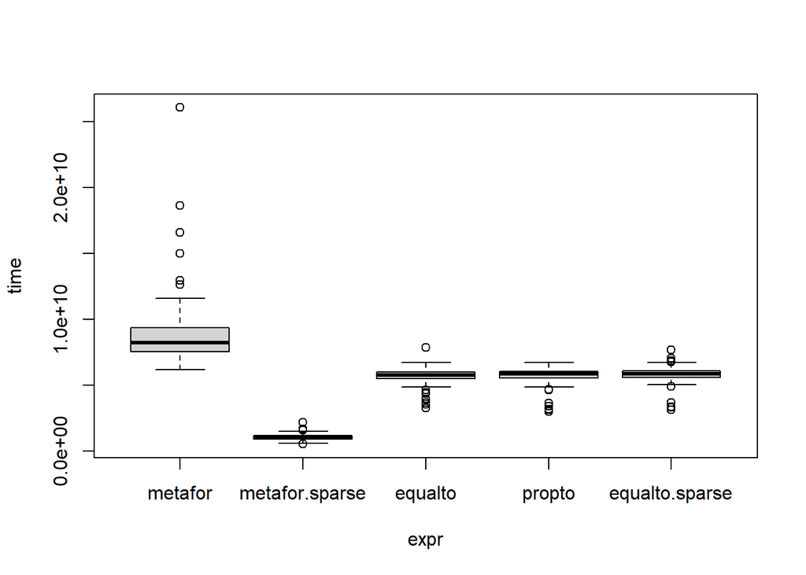

```r
plot(bench_fit)
```

The glmmTMB implementations (equalto and propto) are showing a faster model run time (in seconds) compare to metafor default settings, however they are slower when metafor is used with the `sparse=TRUE` argument that speeds up matrix calculations.

Let’s check the profiling of the glmmTMB model for this dataset to see which parts/functions take the most time:

```r
# Run profiling on model fitted with an average size dataset
Rprof(tmp <- tempfile())
fit.equalto <- glmmTMB(y ~ 1 + (1|study) + equalto(0 + obs|g,VCV),
                       data=dat,
                       REML=T)
Rprof()
prof <- summaryRprof(tmp)
unlink(tmp)


#self.time: Time spent within the function itself, excluding time spent in functions it calls.
self_df <- as.data.frame(prof$by.self) |>
  tibble::rownames_to_column("Function") |>
  dplyr::arrange(desc(self.pct))

#total.time: Time spent in the function including all the time in called functions.
total_df <- as.data.frame(prof$by.total) |>
  tibble::rownames_to_column("Function") |>
  dplyr::arrange(desc(total.pct))

# top 10 by self time
kable(head(self_df, 10), caption = "Top 10 Functions by Self Time (%)")
```

Top 10 Functions by Self Time (%)

| Function | self.time | self.pct | total.time | total.pct |
| --- | --- | --- | --- | --- |
| “.Call” | 1.38 | 88.46 | 1.38 | 88.46 |
| “gc” | 0.10 | 6.41 | 0.10 | 6.41 |
| “eval” | 0.02 | 1.28 | 1.56 | 100.00 |
| “.findMethodInTable” | 0.02 | 1.28 | 0.02 | 1.28 |
| “diffinv” | 0.02 | 1.28 | 0.02 | 1.28 |
| “unique.default” | 0.02 | 1.28 | 0.02 | 1.28 |

```r
# top 10 by total time
kable(head(total_df, 10), caption = "Top 10 Functions by Total Time (%)")
```

Top 10 Functions by Total Time (%)

| Function | total.time | total.pct | self.time | self.pct |
| --- | --- | --- | --- | --- |
| “eval” | 1.56 | 100 | 0.02 | 1.28 |
| “.main” | 1.56 | 100 | 0.00 | 0.00 |
| “block_exec” | 1.56 | 100 | 0.00 | 0.00 |
| “call_block” | 1.56 | 100 | 0.00 | 0.00 |
| “doWithOneRestart” | 1.56 | 100 | 0.00 | 0.00 |
| “eng_r” | 1.56 | 100 | 0.00 | 0.00 |
| “evaluate” | 1.56 | 100 | 0.00 | 0.00 |
| “evaluate::evaluate” | 1.56 | 100 | 0.00 | 0.00 |
| “execute” | 1.56 | 100 | 0.00 | 0.00 |
| “in_dir” | 1.56 | 100 | 0.00 | 0.00 |

What happens if we increase the dataset size by 10-fold (N=5000), let’s simulate a new dataframe (`dat.big`) with 200 studies.

```r
# set up indices
set.seed(123)
k.studies <- 200 # number of studies
k.per.study <- 25 # number of effect sizes per study
study <- rep(seq_len(k.studies), times=k.per.study) # study id
k <- length(study) # total number of effect sizes
id <- seq_len(k) # id of between study effect sizes
es.id <- unlist(lapply(k.per.study, seq_len)) # id of within study effect sizes


# fixed effect coeff true value (i.e. the overall mean)
b0 <- 0

# simulate sampling errors variances
vi <- rbeta(k, 2, 20)

# get VCV matrix assuming within-study correlation of rho=0.5
VCV <- matrix(0, nrow = k, ncol = k)
for (i in 2:k) {
  for (j in 1:i) {
    if (study[i] == study[j]) {
      VCV[i,j] <- 0.5 * sqrt(vi[i] * vi[j])
    }
  }
}
VCV[upper.tri(VCV)] <- t(VCV)[upper.tri(VCV)] # fill in upper diagonal
diag(VCV) <- vi # fill in diagonal


# random effects
sigma2.u <- 0.2
sigma2.m <- 0.3
u <- rnorm(k.studies, 0, sqrt(sigma2.u))[study]
m <- rnorm(k, 0, sqrt(sigma2.m))
#e <- rnorm(k, 0, sqrt(vi))[study] #without within-study correlation (diag VCV)
e <- mvrnorm(n = 1, mu = rep(0, length(vi)), Sigma = VCV) #excluding within-study correlation


# compute y
y <- b0 + u + m + e


# combine into dataframe
dat.big <- data.frame(y = y,
                  vi = vi,
                  study = study,
                  id = id,
                  es.id = es.id,
                  obs = as.factor(id), # unique ID for propto and equalto (really important it is a factor variable)
                  g = 1 # group ID for propto and equalto
)
```

```r
# for propto
colnames(VCV) <- 1:nrow(dat.big)
row.names(VCV) <- 1:nrow(dat.big)

# using the data from the second simulation - this runs 100 times by default
bench_bigfit <- microbenchmark(
  metafor = rma.mv(y, VCV, random = list(~1 | study, ~1 | id),
                   test = "t",
                   dfs = "contain",
                   data=dat.big),
 metafor.sparse = rma.mv(y, VCV, random = list(~1 | study, ~1 | id),
                   test = "t",
                   dfs = "contain",
                   sparse = TRUE, # to speed up run time
                   data=dat.big),
  equalto = glmmTMB(y ~ 1 + (1|study) + equalto(0 + obs|g,VCV),
                    data=dat.big,
                    REML=T),
 times=5
)

bench_bigfit
```

```
Unit: seconds
           expr        min        lq       mean     median         uq
        metafor  346.12620  369.2498  377.59565  384.97010  385.95460
 metafor.sparse   27.72242   28.4635   38.54474   37.25456   48.59139
        equalto 2175.09654 2258.1295 2413.21354 2523.30326 2528.31366
        max neval cld
  401.67758     5 a
   50.69182     5  b
 2581.22467     5   c
```

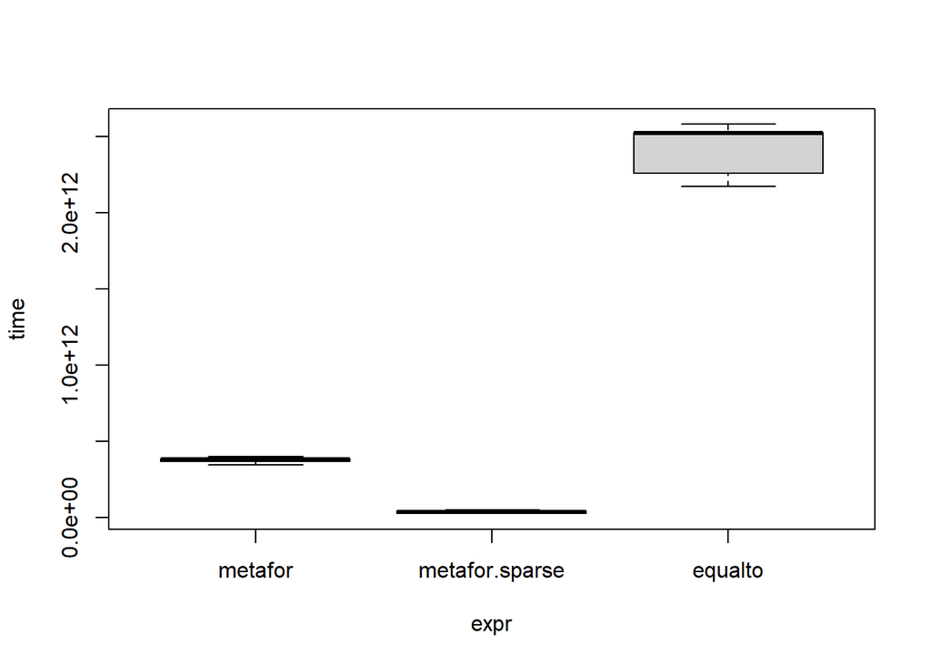

```r
plot(bench_bigfit)
```

**Notes**

Let’s check the profiling of the glmmTMB model for this dataset to see which parts/functions take the most time:

```r
# Run profiling on model fitted with an average size dataset
Rprof(tmp <- tempfile())
fit.equalto <- glmmTMB(y ~ 1 + (1|study) + equalto(0 + obs|g,VCV),
                       data=dat.big,
                       REML=T)
Rprof()
prof <- summaryRprof(tmp)
unlink(tmp)


#self.time: Time spent within the function itself, excluding time spent in functions it calls.
self_df <- as.data.frame(prof$by.self) |>
  tibble::rownames_to_column("Function") |>
  dplyr::arrange(desc(self.pct))

#total.time: Time spent in the function including all the time in called functions.
total_df <- as.data.frame(prof$by.total) |>
  tibble::rownames_to_column("Function") |>
  dplyr::arrange(desc(total.pct))

# top 10 by self time
kable(head(self_df, 10), caption = "Top 10 Functions by Self Time (%)")

# top 10 by total time
kable(head(total_df, 10), caption = "Top 10 Functions by Total Time (%)")
```

[output not shown]

# 6 Next steps….

### 6.0.1 Improve speed

Alternative strategy for `equalto` is to use Gaussian Markov Random Field in TMB cpp that uses the inverse of the covariance matrix: [density::GMRF_t](https://kaskr.github.io/adcomp/classdensity_1_1GMRF__t.html)

### 6.0.2 Further notes

Notes for potential future improvements in implementation:

- For `propto` and `equalto` do not show entire Std.Dev. and correlation matrix of the conditional model (only the `head()`?) in the summary output. When sample size is large it makes it unreadable.
- For `propto` and `equalto` show the random effect component (not scaled).

Notes for future testing of `equalto` cov structure:

- Make an example of a meta-analysis with a non-gaussian distribution (e.g. binomial, poisson) and compare it with `rma.glmm()` function in `metafor`. Speed here should be improved for glmmTMB. Maybe use this as a dataset: https://www.metafor-project.org/doku.php/analyses:stijnen2010.

# 7 References

Viechtbauer, W. (2023). Metafor: Meta-Analysis Package for R. https://cran.r-project.org/web/packages/metafor/index.html

Brooks , M. E., Kristensen, K., van Benthem, K. J., Magnusson, A., Berg, C. W., Nielsen, A., Skaug, H. J., Maechler, M., Bolker, B. M., & Brooks, M. E. (2017). glmmTMB Balances Speed and Flexibility Among Packages for Zero-Inflated Generalized Linear Mixed Modeling. The R Journal, 9(2), 378–400. https://doi.org/10.32614/RJ-2017-066

# 8 Session info

```r
library(sessioninfo)
library(details)

si <- session_info()
details(si, summary = 'Current session info', open = FALSE)
```

**Current session info**

```r
─ Session info ───────────────────────────────────────────────────────────────
 setting  value
 version  R version 4.4.2 (2024-10-31 ucrt)
 os       Windows 11 x64 (build 26100)
 system   x86_64, mingw32
 ui       RTerm
 language (EN)
 collate  English_Australia.utf8
 ctype    English_Australia.utf8
 tz       America/Denver
 date     2025-09-03
 pandoc   3.4 @ C:/Program Files/RStudio/resources/app/bin/quarto/bin/tools/ (via rmarkdown)

─ Packages ───────────────────────────────────────────────────────────────────
 ! package        * version    date (UTC) lib source
   abind            1.4-8      2024-09-12 [1] CRAN (R 4.4.1)
   ape            * 5.8-1      2024-12-16 [1] CRAN (R 4.4.2)
   backports        1.5.0      2024-05-23 [1] CRAN (R 4.4.0)
   bayesplot        1.11.1     2024-02-15 [1] CRAN (R 4.4.1)
   boot             1.3-31     2024-08-28 [1] CRAN (R 4.4.1)
   bridgesampling   1.1-2      2021-04-16 [1] CRAN (R 4.4.1)
   brms           * 2.22.0     2024-09-23 [1] CRAN (R 4.4.1)
   Brobdingnag      1.2-9      2022-10-19 [1] CRAN (R 4.4.1)
   checkmate        2.3.2      2024-07-29 [1] CRAN (R 4.4.1)
   cli              3.6.3      2024-06-21 [1] CRAN (R 4.4.1)
   clipr            0.8.0      2022-02-22 [1] CRAN (R 4.4.1)
   coda             0.19-4.1   2024-01-31 [1] CRAN (R 4.4.3)
   codetools        0.2-20     2024-03-31 [2] CRAN (R 4.4.2)
   colorspace       2.1-1      2024-07-26 [1] CRAN (R 4.4.1)
   desc             1.4.3      2023-12-10 [1] CRAN (R 4.4.1)
   details        * 0.3.0      2022-03-27 [1] CRAN (R 4.4.1)
   digest           0.6.37     2024-08-19 [1] CRAN (R 4.4.1)
   distributional   0.5.0      2024-09-17 [1] CRAN (R 4.4.1)
   dplyr            1.1.4      2023-11-17 [1] CRAN (R 4.4.1)
   emmeans          1.10.6     2024-12-12 [1] CRAN (R 4.4.2)
   estimability     1.5.1      2024-05-12 [1] CRAN (R 4.4.1)
   evaluate         1.0.3      2025-01-10 [1] CRAN (R 4.4.2)
   fastmap          1.2.0      2024-05-15 [1] CRAN (R 4.4.1)
   generics         0.1.3      2022-07-05 [1] CRAN (R 4.4.1)
   ggplot2          3.5.1      2024-04-23 [1] CRAN (R 4.4.1)
   glmmTMB        * 1.1.11     2025-04-03 [1] Github (coraliewilliams/glmmTMB@5872941)
   glue             1.8.0      2024-09-30 [1] CRAN (R 4.4.2)
   gtable           0.3.6      2024-10-25 [1] CRAN (R 4.4.2)
   here           * 1.0.1      2020-12-13 [1] CRAN (R 4.4.1)
   htmltools        0.5.8.1    2024-04-04 [1] CRAN (R 4.4.1)
   htmlwidgets      1.6.4      2023-12-06 [1] CRAN (R 4.4.1)
   httr             1.4.7      2023-08-15 [1] CRAN (R 4.4.1)
   insight        * 1.0.1      2025-01-10 [1] CRAN (R 4.4.1)
   jsonlite         1.8.9      2024-09-20 [1] CRAN (R 4.4.1)
   kableExtra     * 1.4.0      2024-01-24 [1] CRAN (R 4.4.3)
   knitr            1.49       2024-11-08 [1] CRAN (R 4.4.2)
   lattice          0.22-6     2024-03-20 [2] CRAN (R 4.4.2)
   lifecycle        1.0.4      2023-11-07 [1] CRAN (R 4.4.1)
   lme4             1.1-37     2025-03-26 [1] CRAN (R 4.4.2)
   loo              2.8.0      2024-07-03 [1] CRAN (R 4.4.1)
   magrittr         2.0.3      2022-03-30 [1] CRAN (R 4.4.1)
   MASS           * 7.3-64     2025-01-04 [1] CRAN (R 4.4.2)
   mathjaxr         1.6-0      2022-02-28 [1] CRAN (R 4.4.1)
   Matrix         * 1.7-1      2024-10-18 [1] CRAN (R 4.4.2)
   matrixStats      1.5.0      2025-01-07 [1] CRAN (R 4.4.2)
   metadat        * 1.2-0      2022-04-06 [1] CRAN (R 4.4.1)
   metafor        * 4.8-0      2025-01-28 [1] CRAN (R 4.4.3)
   mgcv             1.9-1      2023-12-21 [2] CRAN (R 4.4.2)
   microbenchmark * 1.5.0      2024-09-04 [1] CRAN (R 4.4.1)
   minqa            1.2.8      2024-08-17 [1] CRAN (R 4.4.1)
   multcomp         1.4-26     2024-07-18 [1] CRAN (R 4.4.2)
   munsell          0.5.1      2024-04-01 [1] CRAN (R 4.4.1)
   mvtnorm          1.3-2      2024-11-04 [1] CRAN (R 4.4.2)
   nlme           * 3.1-166    2024-08-14 [1] CRAN (R 4.4.1)
   nloptr           2.2.1      2025-03-17 [1] CRAN (R 4.4.3)
   numDeriv       * 2016.8-1.1 2019-06-06 [1] CRAN (R 4.4.0)
   pillar           1.10.1     2025-01-07 [1] CRAN (R 4.4.2)
   pkgconfig        2.0.3      2019-09-22 [1] CRAN (R 4.4.1)
   png              0.1-8      2022-11-29 [1] CRAN (R 4.4.0)
   posterior        1.6.1      2025-02-27 [1] CRAN (R 4.4.3)
   R6               2.6.1      2025-02-15 [1] CRAN (R 4.4.2)
   rbibutils        2.3        2024-10-04 [1] CRAN (R 4.4.1)
   Rcpp           * 1.0.14     2025-01-12 [1] CRAN (R 4.4.2)
 D RcppParallel     5.1.9      2024-08-19 [1] CRAN (R 4.4.1)
   Rdpack           2.6.3      2025-03-16 [1] CRAN (R 4.4.3)
   reformulas       0.4.0      2024-11-03 [1] CRAN (R 4.4.2)
   rlang            1.1.5      2025-01-17 [1] CRAN (R 4.4.1)
   rmarkdown        2.29       2024-11-04 [1] CRAN (R 4.4.2)
   rprojroot        2.0.4      2023-11-05 [1] CRAN (R 4.4.1)
   rstantools       2.4.0      2024-01-31 [1] CRAN (R 4.4.1)
   rstudioapi       0.17.1     2024-10-22 [1] CRAN (R 4.4.2)
   sandwich         3.1-1      2024-09-15 [1] CRAN (R 4.4.1)
   scales           1.3.0      2023-11-28 [1] CRAN (R 4.4.1)
   sessioninfo    * 1.2.2      2021-12-06 [1] CRAN (R 4.4.1)
   stringi          1.8.4      2024-05-06 [1] CRAN (R 4.4.0)
   stringr          1.5.1      2023-11-14 [1] CRAN (R 4.4.1)
   survival         3.8-3      2024-12-17 [1] CRAN (R 4.4.2)
   svglite          2.1.3      2023-12-08 [1] CRAN (R 4.4.1)
   systemfonts      1.2.0      2025-01-16 [1] CRAN (R 4.4.1)
   tensorA          0.36.2.1   2023-12-13 [1] CRAN (R 4.4.0)
   TH.data          1.1-3      2025-01-17 [1] CRAN (R 4.4.2)
   tibble           3.2.1      2023-03-20 [1] CRAN (R 4.4.1)
   tidyselect       1.2.1      2024-03-11 [1] CRAN (R 4.4.1)
 D TMB              1.9.17     2025-03-10 [1] CRAN (R 4.4.3)
   vctrs            0.6.5      2023-12-01 [1] CRAN (R 4.4.1)
   viridisLite      0.4.2      2023-05-02 [1] CRAN (R 4.4.1)
   withr            3.0.2      2024-10-28 [1] CRAN (R 4.4.2)
   xfun             0.50       2025-01-07 [1] CRAN (R 4.4.2)
   xml2             1.3.6      2023-12-04 [1] CRAN (R 4.4.1)
   xtable           1.8-4      2019-04-21 [1] CRAN (R 4.4.2)
   yaml             2.3.10     2024-07-26 [1] CRAN (R 4.4.1)
   zoo              1.8-12     2023-04-13 [1] CRAN (R 4.4.1)

 [1] C:/Users/z5394590/AppData/Local/R/win-library/4.4
 [2] C:/Program Files/R/R-4.4.2/library

 D ── DLL MD5 mismatch, broken installation.

──────────────────────────────────────────────────────────────────────────────
```